# Estadística - Actividad 3

# Librerías y conexiones

1. Instalamos librerías necesarias

```r
install.packages("openxlsx")
```

2. cargamos las librerías necesarias para leer el archivo excel

```r
library(openxlsx)
library(dplyr)
```

3. cargamos el archivo excel

```r
datos <- read.xlsx("Datos Actividad 3.xlsx", sheet = "Hidrocarburos")
datos
```

|  | Provincia | Municipio | Localidad | Código.postal | Dirección | Precio.gasolina.95.E5 | Precio.gasóleo.A | Tipo.venta | Tipo.servicio | Rótulo |
| --- | --- | --- | --- | --- | --- | --- | --- | --- | --- | --- |
| 1 | ALBACETE | ABENGIBRE | ABENGIBRE | 02250 | AVENIDA CASTILLA LA MANCHA, 26 | 1,529 | 1,419 | P | A | Nº 10.935 |
| 2 | ALBACETE | ALBACETE | ALBACETE | 02001 | CALLE FEDERICO GARCIA LORCA, 5 | NA | 1,560 | R | A | CEPSA |
| 3 | ALBACETE | ALBACETE | ALBACETE | 02001 | CALLE FEDERICO GARCIA LORCA, 1 | 1,409 | 1,399 | P | D | PLENOIL |
| 4 | ALBACETE | ALBACETE | ALBACETE | 02001 | AVENIDA 1º DE MAYO, S/N | 1,539 | 1,489 | P | A | CARREFOUR |
| 5 | ALBACETE | ALBACETE | ALBACETE | 02001 | CALLE PRINCIPE DE ASTURIAS (POLÍGONO DE ROMICA), 5 | 1,549 | 1,549 | P | A | BP ROMICA |
| 6 | ALBACETE | ALBACETE | ALBACETE | 02005 | AVENIDA MENÉNDEZ PIDAL, 58 | 1,569 | 1,529 | P | A | TAMOS |
| 7 | ALBACETE | ALBACETE | ALBACETE | 02005 | CL PASEO DE LA CUBA, 15 | 1,579 | 1,549 | P | A | REPSOL |
| 8 | ALBACETE | ALBACETE | ALBACETE | 02005 | AVENIDA ESCRITOR RODRIGO RUBIO, 3 | 1,498 | 1,387 | P | NA | A&A |
| 9 | ALBACETE | ALBACETE | ALBACETE | 02005 | PASEO CUBA (LA), 36 | 1,579 | 1,579 | P | P | CEPSA |
| 10 | ALBACETE | ALBACETE | ALBACETE | 02002 | CALLE HERMANOS FALCÓ, 2 | 1,599 | 1,579 | P | NA | CEPSA |

[output cut: 990 more lines]

# Tarea 1

## Parte 1

1. Filtramos el conjunto de datos según provincia

```r
df2 <- datos |> filter(Provincia %in% c("MADRID", "BARCELONA", "SEVILLA"))
df2
```

| Provincia | Municipio | Localidad | Código.postal | Dirección | Precio.gasolina.95.E5 | Precio.gasóleo.A | Tipo.venta | Tipo.servicio | Rótulo |
| --- | --- | --- | --- | --- | --- | --- | --- | --- | --- |
| BARCELONA | ABRERA | ENTITAT EST D'ABRERA | 08630 | CALLE HOSTAL DEL PI S/N, S/N | 1,549 | 1,489 | P | A | NIEVES |
| BARCELONA | ABRERA | ABRERA | 08630 | CALLE SALVADOR SEGUI,1, | 1,559 | 1,499 | P | NA | GALP |
| BARCELONA | ABRERA | ABRERA | 08630 | CALLE TREBALL, 1 | NA | 1,499 | P | A | HAM |
| BARCELONA | ABRERA | ABRERA | 08630 | AVENIDA ENERGIA, 9 | NA | 1,370 | P | A | BALTRAN S.A |
| BARCELONA | ABRERA | ABRERA | 08630 | PASAJE TREBALL DEL, 1 | NA | NA | P | A | HAM |
| BARCELONA | ABRERA | ABRERA | 08630 | AVENIDA ENERGIA, 10 | NA | 1,363 | R | A | TRANSPORTES SOLAZO |
| BARCELONA | ALELLA | ALELLA | 08328 | CARRER RIERA, 48 | 1,599 | 1,519 | P | D | AUTONETOIL |
| BARCELONA | ALELLA | ALELLA | 08328 | CARRETERA ALELLA KM. 1 | 1,659 | 1,579 | P | A | BP ALELLA |
| BARCELONA | AMETLLA DEL VALLÈS (L') | AMETLLA DEL VALLES (L') | 08480 | CALLE SECTOR MAS DORCA, 2 | 1,489 | 1,379 | P | A | PETROLIS INDEPENDENTS - PETRO7 |
| BARCELONA | AMETLLA DEL VALLÈS (L') | SERRAT DE L'OCATA | 08480 | CR C-17, 26,65 | 1,599 | 1,569 | P | A | PETROCAT |

[output cut: 990 more lines]

2. formateamos los campos de precio

```r
df2$Precio.gasolina.95.E5 <- gsub(",", ".", df2$Precio.gasolina.95.E5)
df2$Precio.gasóleo.A <- gsub(",", ".", df2$Precio.gasóleo.A)
```

3. setamos los campos precio como numéricos

```r
df2$Precio.gasolina.95.E5 <- as.numeric(df2$Precio.gasolina.95.E5)
df2$Precio.gasóleo.A <- as.numeric(df2$Precio.gasóleo.A)
df2
```

| Provincia | Municipio | Localidad | Código.postal | Dirección | Precio.gasolina.95.E5 | Precio.gasóleo.A | Tipo.venta | Tipo.servicio | Rótulo |
| --- | --- | --- | --- | --- | --- | --- | --- | --- | --- |
| BARCELONA | ABRERA | ENTITAT EST D'ABRERA | 08630 | CALLE HOSTAL DEL PI S/N, S/N | 1.549 | 1.489 | P | A | NIEVES |
| BARCELONA | ABRERA | ABRERA | 08630 | CALLE SALVADOR SEGUI,1, | 1.559 | 1.499 | P | NA | GALP |
| BARCELONA | ABRERA | ABRERA | 08630 | CALLE TREBALL, 1 | NA | 1.499 | P | A | HAM |
| BARCELONA | ABRERA | ABRERA | 08630 | AVENIDA ENERGIA, 9 | NA | 1.370 | P | A | BALTRAN S.A |
| BARCELONA | ABRERA | ABRERA | 08630 | PASAJE TREBALL DEL, 1 | NA | NA | P | A | HAM |
| BARCELONA | ABRERA | ABRERA | 08630 | AVENIDA ENERGIA, 10 | NA | 1.363 | R | A | TRANSPORTES SOLAZO |
| BARCELONA | ALELLA | ALELLA | 08328 | CARRER RIERA, 48 | 1.599 | 1.519 | P | D | AUTONETOIL |
| BARCELONA | ALELLA | ALELLA | 08328 | CARRETERA ALELLA KM. 1 | 1.659 | 1.579 | P | A | BP ALELLA |
| BARCELONA | AMETLLA DEL VALLÈS (L') | AMETLLA DEL VALLES (L') | 08480 | CALLE SECTOR MAS DORCA, 2 | 1.489 | 1.379 | P | A | PETROLIS INDEPENDENTS - PETRO7 |
| BARCELONA | AMETLLA DEL VALLÈS (L') | SERRAT DE L'OCATA | 08480 | CR C-17, 26,65 | 1.599 | 1.569 | P | A | PETROCAT |

[output cut: 990 more lines]

4. Análisis del dataset

   4.1. Análisis general

```r
summary(df2)
```

```
  Provincia          Municipio          Localidad         Código.postal
 Length:2123        Length:2123        Length:2123        Length:2123
 Class :character   Class :character   Class :character   Class :character
 Mode  :character   Mode  :character   Mode  :character   Mode  :character




  Dirección         Precio.gasolina.95.E5 Precio.gasóleo.A  Tipo.venta
 Length:2123        Min.   :1.319         Min.   :1.215    Length:2123
 Class :character   1st Qu.:1.479         1st Qu.:1.399    Class :character
 Mode  :character   Median :1.589         Median :1.539    Mode  :character
                    Mean   :1.554         Mean   :1.492
                    3rd Qu.:1.619         3rd Qu.:1.579
                    Max.   :1.749         Max.   :1.729
                    NA's   :132           NA's   :57
 Tipo.servicio         Rótulo
 Length:2123        Length:2123
 Class :character   Class :character
 Mode  :character   Mode  :character
```

```
4.2. Análisis por provincia (Gasolina 95 E5)
```

```r
# Según Precio.gasolina.95.E5
res_provincia_95E5 <- df2 %>%
  group_by(Provincia) %>%
  summarise(
    cantidad = n(),
    promedio = mean(Precio.gasolina.95.E5, na.rm = TRUE),
    max = max(Precio.gasolina.95.E5, na.rm = TRUE),
    min = min(Precio.gasolina.95.E5, na.rm = TRUE),
    mediana = median(Precio.gasolina.95.E5, na.rm = TRUE),
    varianza = var(Precio.gasolina.95.E5, na.rm = TRUE)
  )

print(res_provincia_95E5)
```

| Provincia | cantidad | promedio | max | min | mediana | varianza |
| --- | --- | --- | --- | --- | --- | --- |
| BARCELONA | 805 | 1.554532 | 1.689 | 1.347 | 1.589 | 0.009517317 |
| MADRID | 852 | 1.560661 | 1.749 | 1.389 | 1.589 | 0.005471028 |
| SEVILLA | 466 | 1.538608 | 1.719 | 1.319 | 1.569 | 0.007559191 |

```
4.3. Graficamos los resultados
```

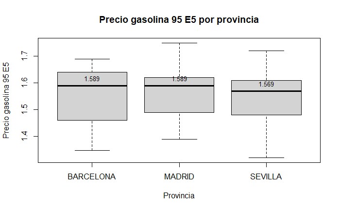

```r
# Según Precio.gasolina.95.E5 creamos un boxplot por provincia con etiquetas

boxplot(df2$Precio.gasolina.95.E5 ~ df2$Provincia, main = "Precio gasolina 95 E5 por provincia", xlab = "Provincia", ylab = "Precio gasolina 95 E5")

# Agregamos las etiquetas para mejorar la visibilidad
# Calcular las medianas para cada provincia
medianas <- tapply(df2$Precio.gasolina.95.E5, df2$Provincia, median, na.rm = TRUE)

# Agregar etiquetas de texto para las medianas
text(x = 1:length(medianas), y = medianas, labels = format(medianas, digits = 4), pos = 3, cex = 0.8)
```

```
4.4. Análisis por provincia (Gasóleo A)
```

```r
# Según Precio.gasóleo.A
res_provincia_gasA <- df2 %>%
  group_by(Provincia) %>%
  summarise(
    cantidad = n(),
    promedio = mean(Precio.gasóleo.A, na.rm = TRUE),
    max = max(Precio.gasóleo.A, na.rm = TRUE),
    min = min(Precio.gasóleo.A, na.rm = TRUE),
    mediana = median(Precio.gasóleo.A, na.rm = TRUE),
    varianza = var(Precio.gasóleo.A, na.rm = TRUE),
  )

print(res_provincia_gasA)
```

| Provincia | cantidad | promedio | max | min | mediana | varianza |
| --- | --- | --- | --- | --- | --- | --- |
| BARCELONA | 805 | 1.483461 | 1.649 | 1.239 | 1.519 | 0.008788877 |
| MADRID | 852 | 1.505422 | 1.709 | 1.249 | 1.559 | 0.010307070 |
| SEVILLA | 466 | 1.484377 | 1.729 | 1.215 | 1.530 | 0.014010646 |

```
4.5. Graficamos los resultados
```

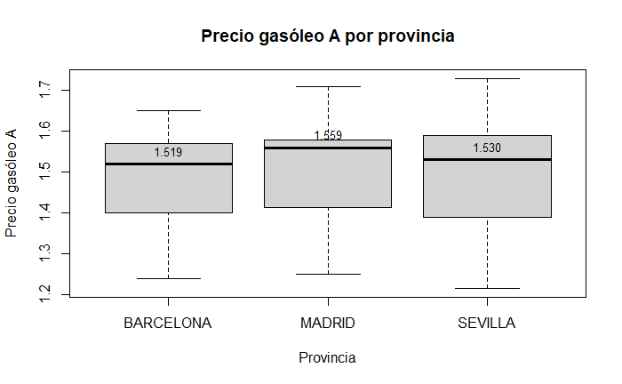

```r
# Según Precio.gasóleo.A creamos un boxplot por provincia con etiquetas

boxplot(df2$Precio.gasóleo.A ~ df2$Provincia, main = "Precio gasóleo A por provincia", xlab = "Provincia", ylab = "Precio gasóleo A")

# Agregamos las etiquetas para mejorar la visibilidad
# Calcular las medianas para cada provincia
medianas <- tapply(df2$Precio.gasóleo.A, df2$Provincia, median, na.rm = TRUE)

# Agregar etiquetas de texto para las medianas
text(x = 1:length(medianas), y = medianas, labels = format(medianas, digits = 4), pos = 3, cex = 0.8)
```

5. Análisis de correlación entre los precios en provincias

   5.1 Precio gasolina 95 E5, podemos concluir del resúmen y el gráfico que el precio medio (mediana) de la gasolina 95 Es es mayor en la provincia de Barcelona y Madrid, seguido de Sevilla. Además Sevilla cuenta con el menor precio de gasolina de 95 y Madrid, con el mayor. La variabilidad de los precios es diferente en cada provincia a pesar que entre Barcelona y Madrid comparten el mismo precio medio (mediana)

   5.2 Precio gasóleo A, podemos concluir del resúmen y el gráfico que el precio medio (mediana) del gasóleo A es mayor en la provincia de Madrid, seguido de Sevilla y Barcelona. Además Sevilla cuenta al mismo tiempo con el menor precio de gasóleo A y también con el mayor.La variabilidad de los precios es en Barcelona y Madrid es muy similar (aproximados) a pesar de tener precios medios (medianas) diferentes.

# Tarea 2

1. Creamos los conjuntos de datos

Madrid - Otros

```r
madrid_otros <- datos |> filter(Provincia %in% c("MADRID", "SEVILLA", "BARCELONA", "VALENCIA"))
```

```
1.1 Creamos el campo "agrupación", si si la Provincia es diferente de Madrid, se colocará "Otros".
```

```r
madrid_otros$provincia_grp <- ifelse(madrid_otros$Provincia == "MADRID", "MADRID", "OTROS")
madrid_otros
```

| Provincia | Municipio | Localidad | Código.postal | Dirección | Precio.gasolina.95.E5 | Precio.gasóleo.A | Tipo.venta | Tipo.servicio | Rótulo | provincia_grp |
| --- | --- | --- | --- | --- | --- | --- | --- | --- | --- | --- |
| BARCELONA | ABRERA | ENTITAT EST D'ABRERA | 08630 | CALLE HOSTAL DEL PI S/N, S/N | 1,549 | 1,489 | P | A | NIEVES | OTROS |
| BARCELONA | ABRERA | ABRERA | 08630 | CALLE SALVADOR SEGUI,1, | 1,559 | 1,499 | P | NA | GALP | OTROS |
| BARCELONA | ABRERA | ABRERA | 08630 | CALLE TREBALL, 1 | NA | 1,499 | P | A | HAM | OTROS |
| BARCELONA | ABRERA | ABRERA | 08630 | AVENIDA ENERGIA, 9 | NA | 1,370 | P | A | BALTRAN S.A | OTROS |
| BARCELONA | ABRERA | ABRERA | 08630 | PASAJE TREBALL DEL, 1 | NA | NA | P | A | HAM | OTROS |
| BARCELONA | ABRERA | ABRERA | 08630 | AVENIDA ENERGIA, 10 | NA | 1,363 | R | A | TRANSPORTES SOLAZO | OTROS |
| BARCELONA | ALELLA | ALELLA | 08328 | CARRER RIERA, 48 | 1,599 | 1,519 | P | D | AUTONETOIL | OTROS |
| BARCELONA | ALELLA | ALELLA | 08328 | CARRETERA ALELLA KM. 1 | 1,659 | 1,579 | P | A | BP ALELLA | OTROS |
| BARCELONA | AMETLLA DEL VALLÈS (L') | AMETLLA DEL VALLES (L') | 08480 | CALLE SECTOR MAS DORCA, 2 | 1,489 | 1,379 | P | A | PETROLIS INDEPENDENTS - PETRO7 | OTROS |
| BARCELONA | AMETLLA DEL VALLÈS (L') | SERRAT DE L'OCATA | 08480 | CR C-17, 26,65 | 1,599 | 1,569 | P | A | PETROCAT | OTROS |

[output cut: 990 more lines]

2. Formateamos los campos de precio

   2.1. Reemplazamos las comas por puntos

```r
madrid_otros$Precio.gasolina.95.E5 <- gsub(",", ".", df2$Precio.gasolina.95.E5)
madrid_otros$Precio.gasóleo.A <- gsub(",", ".", df2$Precio.gasóleo.A)
```

```
2.2. setamos los campos precio como numéricos
```

```r
madrid_otros$Precio.gasolina.95.E5 <- as.numeric(df2$Precio.gasolina.95.E5)
madrid_otros$Precio.gasóleo.A <- as.numeric(df2$Precio.gasóleo.A)
```

3. Analizamos las varianzas

```r
# Realizar la prueba F para Madrid y Sevilla
var.test(Precio.gasolina.95.E5 ~ provincia_grp, data = madrid_otros,
         conf.level = 0.95, alternative = 'two.sided')
```

```
    F test to compare two variances

data:  Precio.gasolina.95.E5 by provincia_grp
F = 0.61685, num df = 811, denom df = 1178, p-value = 2.153e-13
alternative hypothesis: true ratio of variances is not equal to 1
95 percent confidence interval:
 0.5439290 0.7005869
sample estimates:
ratio of variances
         0.6168462
```

4. Testeamos la hipótesis ($H_0:μ1-μ2=0$ $H_2:μ1-μ2≠0$)

   4.1. Precio de gasolina 95 E en Madrid vs Otras provincias

$H_0:μ1-μ2=0$

```r
t.test(madrid_otros$Precio.gasolina.95.E5 ~ madrid_otros$provincia_grp,
       conf.level = 0.99,
       mu = 0,
       alternative = c("two.sided"),
       var.equal = TRUE)
```

```
    Two Sample t-test

data:  madrid_otros$Precio.gasolina.95.E5 by madrid_otros$provincia_grp
t = 2.995, df = 1989, p-value = 0.002778
alternative hypothesis: true difference in means between group MADRID and group OTROS is not equal to 0
99 percent confidence interval:
 0.001644004 0.021987392
sample estimates:
mean in group MADRID  mean in group OTROS
            1.560661             1.548846
```

$H_2:μ1-μ2≠0$

```r
t.test(madrid_otros$Precio.gasolina.95.E5 ~ madrid_otros$provincia_grp,
       conf.level = 0.99,
       mu = 0,
       alternative = c("two.sided"),
       var.equal = FALSE)
```

```
    Welch Two Sample t-test

data:  madrid_otros$Precio.gasolina.95.E5 by madrid_otros$provincia_grp
t = 3.1289, df = 1955.1, p-value = 0.00178
alternative hypothesis: true difference in means between group MADRID and group OTROS is not equal to 0
99 percent confidence interval:
 0.00207907 0.02155233
sample estimates:
mean in group MADRID  mean in group OTROS
            1.560661             1.548846
```

```
4.2. Precio de gasóleo A en Madrid vs Otras provincias
```

$H_0:μ1-μ2=0$

```r
t.test(madrid_otros$Precio.gasóleo.A ~ madrid_otros$provincia_grp,
       conf.level = 0.99,
       mu = 0,
       alternative = c("two.sided"),
       var.equal = TRUE)
```

```
    Two Sample t-test

data:  madrid_otros$Precio.gasóleo.A by madrid_otros$provincia_grp
t = 4.6826, df = 2064, p-value = 3.017e-06
alternative hypothesis: true difference in means between group MADRID and group OTROS is not equal to 0
99 percent confidence interval:
 0.009717579 0.033529213
sample estimates:
mean in group MADRID  mean in group OTROS
            1.505422             1.483799
```

$H_2:μ1-μ2≠0$

```r
t.test(madrid_otros$Precio.gasóleo.A ~ madrid_otros$provincia_grp,
       conf.level = 0.99,
       mu = 0,
       alternative = c("two.sided"),
       var.equal = FALSE)
```

```
    Welch Two Sample t-test

data:  madrid_otros$Precio.gasóleo.A by madrid_otros$provincia_grp
t = 4.7008, df = 1775.4, p-value = 2.791e-06
alternative hypothesis: true difference in means between group MADRID and group OTROS is not equal to 0
99 percent confidence interval:
 0.009761985 0.033484807
sample estimates:
mean in group MADRID  mean in group OTROS
            1.505422             1.483799
```

# Conclusiones

Respecto a la gasolina 95 E5, podemos concluir con un 99% de confianza que el precio medio de la gasolina 95 E es mayor en Madrid que en otras provincias.

Respecto al gasóleo A, podemos concluir con un 99% de confianza que el precio medio del gasóleo A es mayor en Madrid que en otras provincias.